# Blurring the Marriage Market?

Contemporary Patterns of Multiracial Marriage

[Aaron Gullickson](https://aarongullickson.netlify.app/)

aarong@uoregon.edu

University of Oregon

Jenifer Bratter

jbratter@rice.edu

Rice University

## In Memoriam

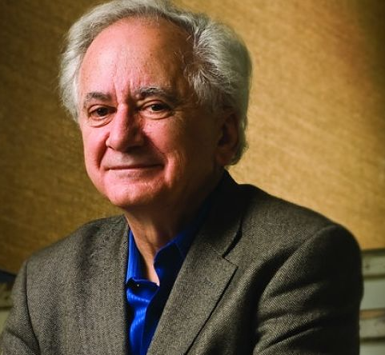

Richard Alba

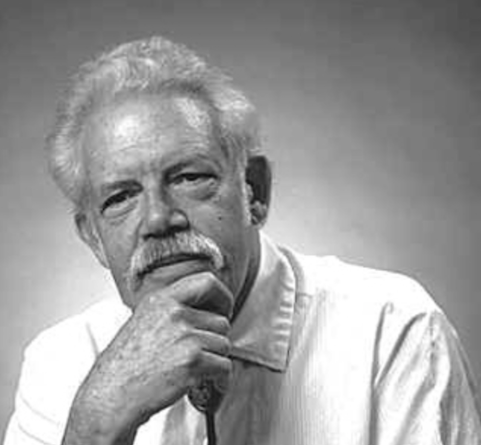

Eugene Hammel

## The Biracial Baby Boom

[figure not shown]

## Who do Multiracial Individuals Marry?

### Future racial composition

[figure not shown]

New Eve

### Current racial boundaries

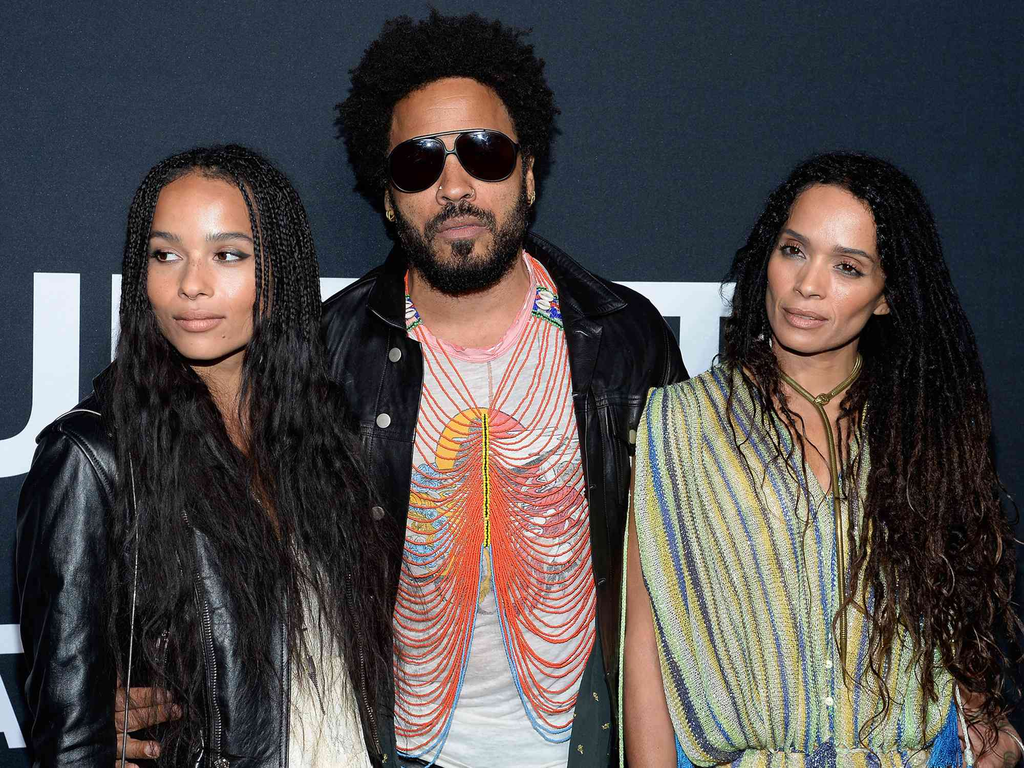

The Kravitz-Bonet Family

## Multiraciality and Post-Racialism

*“The greatest hope for the immediate future lies in a lessening of the contrast between Negroes and whites… In a race of octoroons, living among whites, the color question would probably disappear.”*

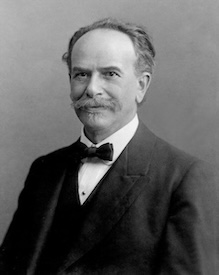

Franz Boas

- Multiracial individuals have long been seen as the vanguard of a post-racial future.
- Both popular and scholarly work focuses almost exclusively on the experience of first generation “biracial” individuals.
- Mixed race identity is treated as an absorbing state. The empirical evidence suggests otherwise:
  - Bratter (2007) shows that the children of multiracial parents are often identified by the single race shared with the other parent.
  - For mixed-race individuals with a deeper *generational locus*, multiracial ancestry may “fold back” into single race identification and classification.

## A Multigenerational Process

```
flowchart LR

%% Colors %%

classDef blue fill:#1F4E79,stroke:#000,color:#fff
classDef green fill:#6B2C3E,stroke:#000,color:#fff

%% GENERATION 4 %%
Fa1(White Man):::green --> G31(Interracial Marriage):::blue
Mo1(Asian Woman):::green --> G31

Fa2(White Man):::green --> G32(Same Race Marriage):::blue
Mo2(White Woman):::green --> G32


%% GENERATION 3 %%
G31 --> Fa(White-Asian Man):::green --> G2("Interracial (?) Marriage"):::blue
G32 --> Mo(White Woman):::green --> G2

%% GENERATION 2 %%
G2 --> Or(?):::green
```

## Simulation Produces Surprising Results

[figure not shown]

## Concept of Partial Endogamy

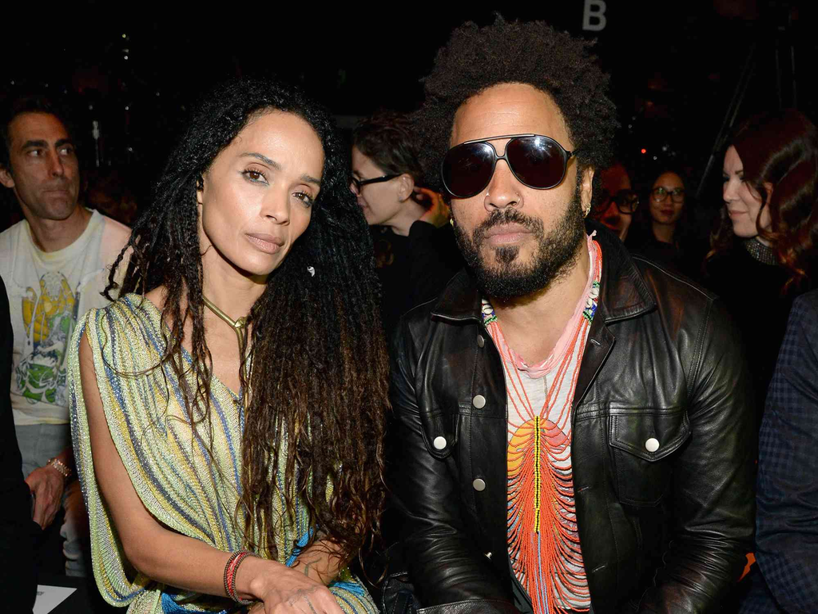

Exact Match

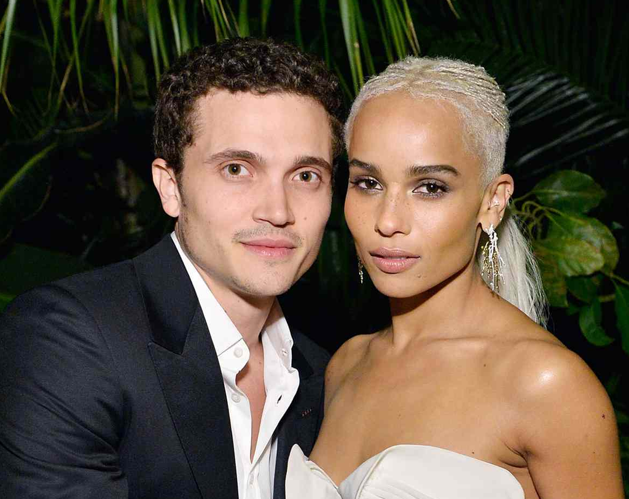

Partial Overlap

### What does “endogamy” mean for individuals of mixed race?

- A person might prefer a partner who shares the same racial mixture as themselves, leading to an *exact* match.
- But what if a Black-White individual marries a White person? Is this endogamy or exogamy?
- We consider this case of a *partial overlap* in racial identification to indicate *partial endogamy*.
- We expect partial endogamy to increase the likelihood of partnership but not as much as an *exact* match, adjusting for group sizes.

## Not All Partial Endogamy is Equal

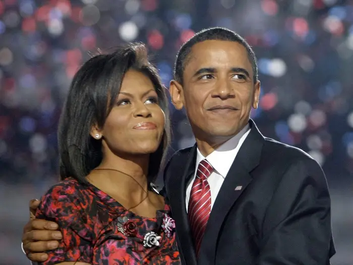

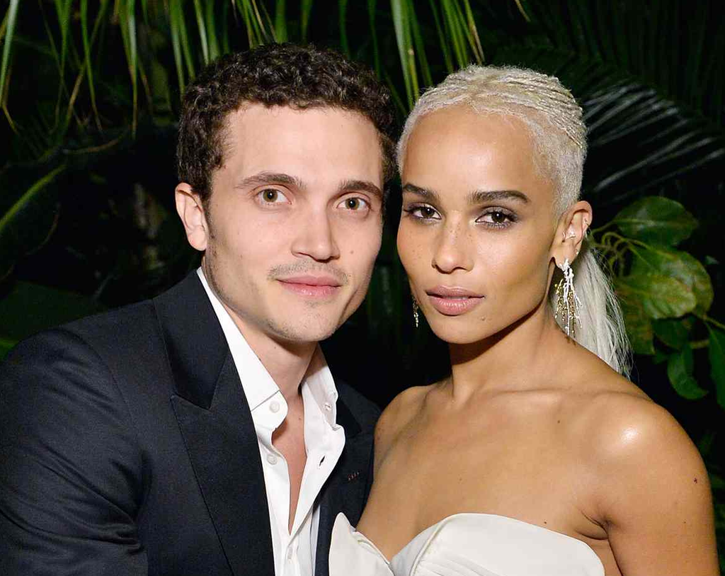

- *Regimes of racial classification* have long determined the racial classification of mixed race individuals.
  - **The One Drop Rule**: Black ancestry dominates.
  - **The Vanishing Indian**: Indigenous ancestry recedes.
  - White ancestry falls somewhere in the middle of these extremes.
  - Greater flexibility/less historical precedent for the racial classification of Asian and Latino ancestry.
- We expect these regimes to affect the likelihood of partnership for multiracial individuals because it reflects how they are viewed as potential partners.

## Other Possible Patterns

### Shared Experience

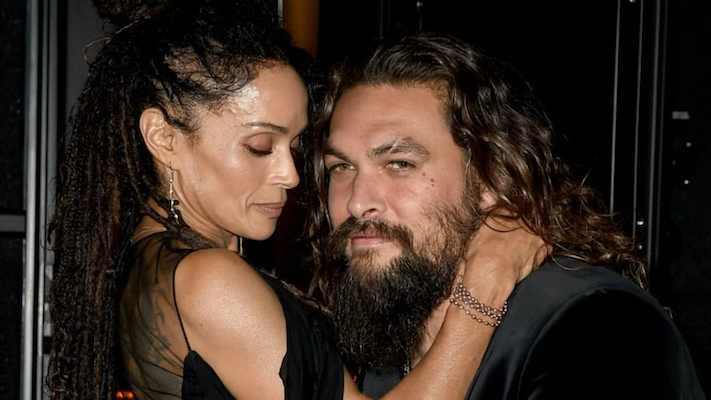

It is possible that the *shared experience of being multiracial* itself contributes to partner formation, regardless of specific ancestry.

### Transcendent Pattern

[figure not shown]

We might also expect a *transcendent pattern* in which multiracial individuals are more likely to cross racial boundaries in marriage generally.

## Data Sources

- American Community Survey (ACS) data from 2010-2019.
- All opposite sex couples who were married in the last five years.
- We use five large panethnic racial categories to sustain sample size for the analysis:
  - White
  - Black
  - Asian
  - Indigenous (American Indian, Alaska Native, and Pacific Islander)
  - Latino (identified via Hispanicity question)

**Caution**

Due to the combined question format of the ACS, we cannot identify multiracial individuals of part-Latino ancestry.

## Sample Size by Race

|  | Marriages Wife | Marriages Husband | Alternates Women | Alternates Men |
| --- | --- | --- | --- | --- |
| White | 607,851 | 611,462 | 4,145,979 | 3,524,686 |
| Black | 52,178 | 60,647 | 928,698 | 725,355 |
| Asian | 34,638 | 26,738 | 244,873 | 199,473 |
| Indigenous | 7,664 | 7,503 | 73,275 | 67,826 |
| Latino | 114,115 | 111,099 | 806,054 | 750,814 |
| White-Indigenous | 4,737 | 4,446 | 36,251 | 34,845 |
| White-Asian | 4,491 | 3,923 | 24,644 | 24,731 |
| White-Black | 2,616 | 2,544 | 24,628 | 21,938 |
| Black-Indigenous | 424 | 481 | 7,719 | 6,891 |
| Black-Asian | 351 | 323 | 3,093 | 2,667 |
| Asian-Indigenous | 420 | 319 | 3,117 | 3,083 |
| Total | 829,485 | 829,485 | 6,298,331 | 5,362,309 |

## Race of Partner for Multiracial Spouses

[figure not shown]

## Modeling Partner Choice

[figure not shown]

## Multiracial-to-Multiracial Intermarriage

[figure not shown]

## Simplified Multiracial-to-Multiracial Model

[figure not shown]

## Multiracial-to-Monoracial Intermarriage

[figure not shown]

## Conclusions

- A high level of endogamy exists among multiracial individuals, masked by small group sizes.
- Partial overlap in racial identification increases the likelihood of partnering, but patterned by historical racial regimes.
  - Shared Black ancestry matters most.
  - Shared Indigenous ancestry matters least.
  - Shared White and Asian ancestry are somewhere in-between.
- No evidence of a postracial or transcendent pattern in partner choices.
- Despite a high level of endogamy, multiracial individuals are most likely to marry single-race individuals because of the small size of groups.
  - Inhibits formation of a sense of group identity.
  - part-White multiracial individuals are most likely to marry White partners, suggesting that multiracial identity may “fold” back into single race categories in the next generation.

[figure not shown]

- Thank you for your time and questions!
- Check out the paper now out in *Demography*!

[figure not shown]

Article Link

[figure not shown]

Replication Package

## Latino Patterns of Intermarriage

[figure not shown]

## Gender-Specific Patterns

[figure not shown]